# Expected lifetime

useR member

# Setup

# How to use revealjs

- First, install the revealjs package `install.packages(revealjs)`
- Now set the output in your yaml:

```
---
title: my title
author: my name
output:
    revealjs::revealjs_presentation
---
```

# Build

- Now build like normal!
- Click rstudio button or use `rmarkdown::render("file.Rmd")`
- See github readme for options:

rstudio/revealjs

# Intro

# The study

- Three species of fish, cutthroat, rainbow, and grayling exposed to biological agent.
- Time until death after exposure is recorded.
- Some observations are censored; we have last known time alive.

# Objective

- Estimate average time until death after exposure for each species.
- Difference in average time until death between cutthroat and rainbow.

# Data

# Number of fish

[interactive chart not shown]

# Time until death

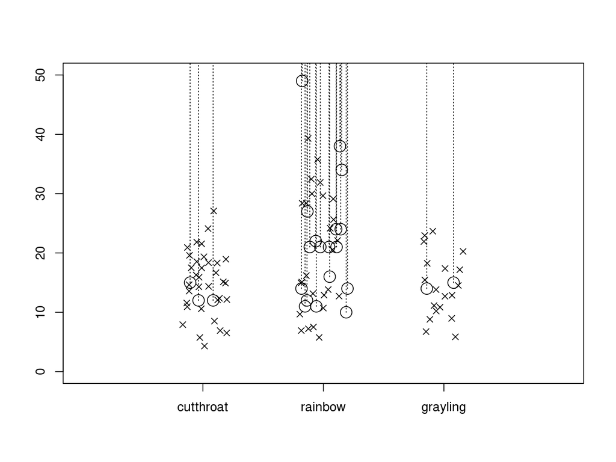

# Model

# Parameters and variables

- $\mu_j$ is the average lifetime of species $j$.
- $\sigma$ is the assumed constant across species standard deviation of lifetime.
- $y_i$ is the lifetime of the $i^\text{th}$ fish.
- $j[i]$ is the species of the $i^\text{th}$ fish.

# Likelihood

I assume lifetime follows a normal distribution.

$y_i \sim N(\mu_{j[i]}, \sigma^2)$

# Prior

$\mu_j \sim N(20, 10)$

$\sigma \sim N(0, 10)_+$

($\sigma$ is constrained to be positive)

# Censored?

- Likelihood tells us how we get our data from the parameters.
- We have $y\sim N(\mu, \sigma^2)$ and we want to probability of $y>C$.
- This is just the upper “tail” of $N(\mu, \sigma^2)$ greater than $C$.

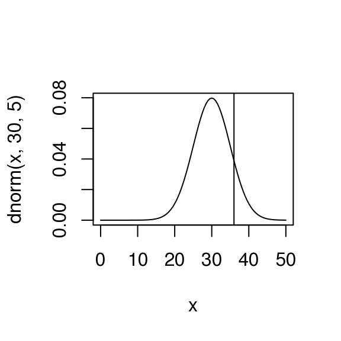

```r
curve(dnorm(x, 30, 5), xlim = c(0, 50))
abline(v = 36)
```

# Stan code

```
data {
    int<lower=0> n1obs;
    int<lower=0> n2obs;
    int<lower=0> n3obs;
    int<lower=0> n1cens;
    int<lower=0> n2cens;
    int<lower=0> n3cens;
    real y1obs[n1obs];
    real y2obs[n2obs];
    real y3obs[n3obs];
    real y1cens[n1cens];
    real y2cens[n2cens];
    real y3cens[n3cens];
}

parameters {
    real<lower=0> mu1;
    real<lower=0> mu2;
    real<lower=0> mu3;
    real<lower=0> sigma;
}

model {
    mu1 ~ normal(20, 10);
    mu2 ~ normal(20, 10);
    mu3 ~ normal(20, 10);
    sigma ~ normal(0, 10);
    y1obs ~ normal(mu1, sigma);
    y2obs ~ normal(mu2, sigma);
    y3obs ~ normal(mu3, sigma);
    increment_log_prob(normal_ccdf_log(y1cens, mu1, sigma));
    increment_log_prob(normal_ccdf_log(y2cens, mu2, sigma));
    increment_log_prob(normal_ccdf_log(y3cens, mu3, sigma));
}

generated quantities {
    real cut_rain;

    cut_rain <- mu1 - mu2;
}
```

# Fit model and evaluate

# Traceplot

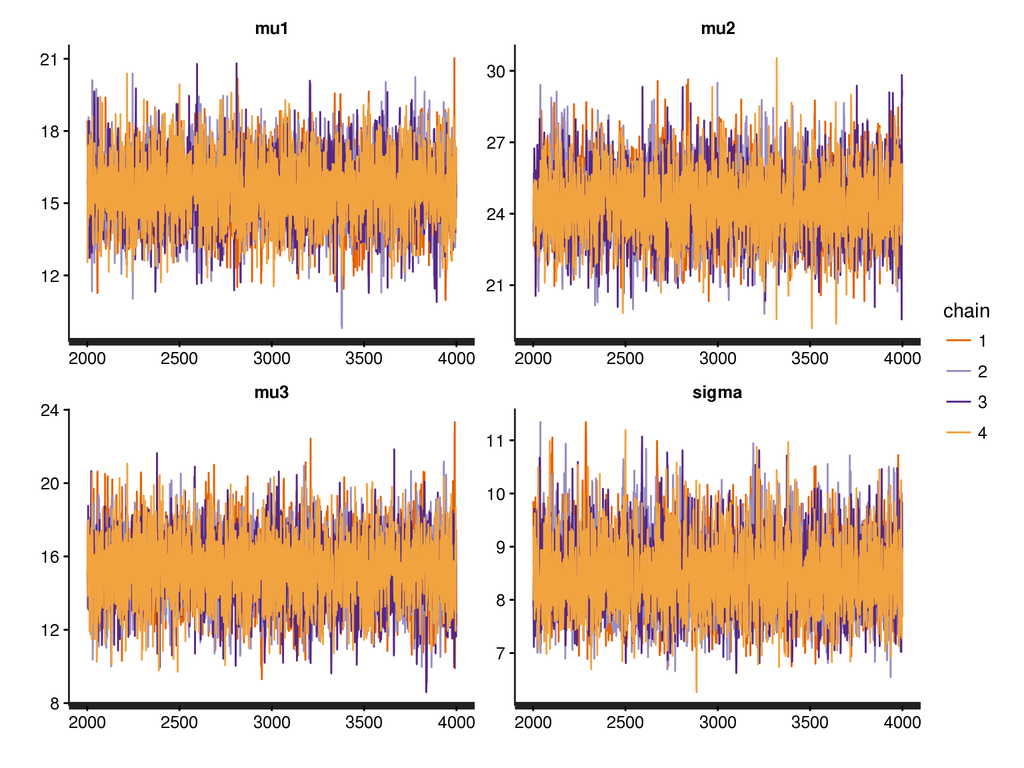

# Summary

```
## Inference for Stan model: lifetime.
## 4 chains, each with iter=4000; warmup=2000; thin=1;
## post-warmup draws per chain=2000, total post-warmup draws=8000.
##
##             mean se_mean   sd    2.5%     25%     50%     75%   97.5%
## mu1        15.53    0.02 1.40   12.86   14.60   15.52   16.44   18.29
## mu2        24.42    0.02 1.43   21.67   23.47   24.40   25.35   27.31
## mu3        15.22    0.03 1.84   11.63   13.96   15.20   16.45   18.80
## sigma       8.46    0.01 0.70    7.24    7.96    8.40    8.89    9.98
## cut_rain   -8.89    0.03 1.99  -12.91  -10.20   -8.84   -7.54   -5.14
## lp__     -211.13    0.03 1.46 -214.92 -211.80 -210.78 -210.06 -209.31
##          n_eff Rhat
## mu1       5587    1
## mu2       5242    1
## mu3       5137    1
## sigma     4592    1
## cut_rain  5392    1
## lp__      2274    1
##
## Samples were drawn using NUTS(diag_e) at Wed Mar 16 23:24:40 2016.
## For each parameter, n_eff is a crude measure of effective sample size,
## and Rhat is the potential scale reduction factor on split chains (at
## convergence, Rhat=1).
```

# Results

# Average lifetime for cutthroat

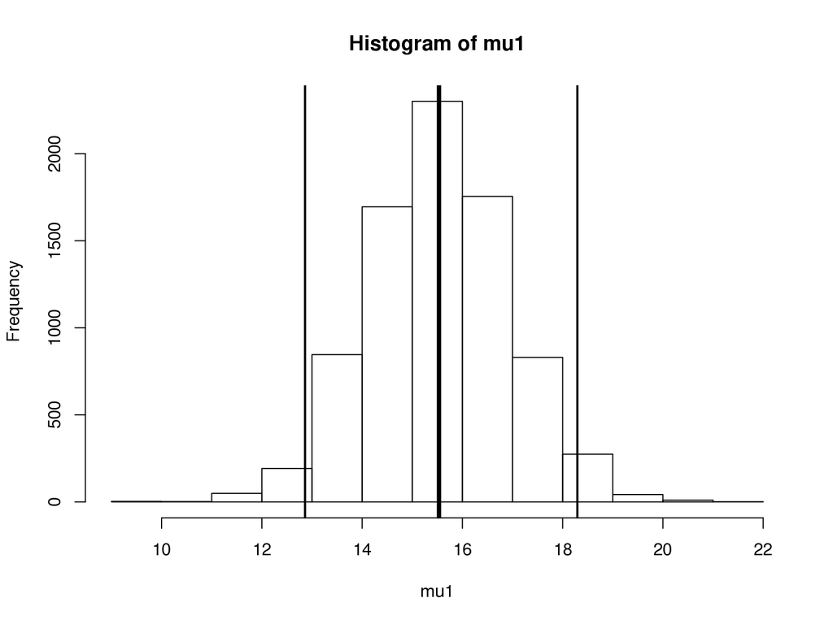

# Difference in average lifetime between cutthroat and rainbow

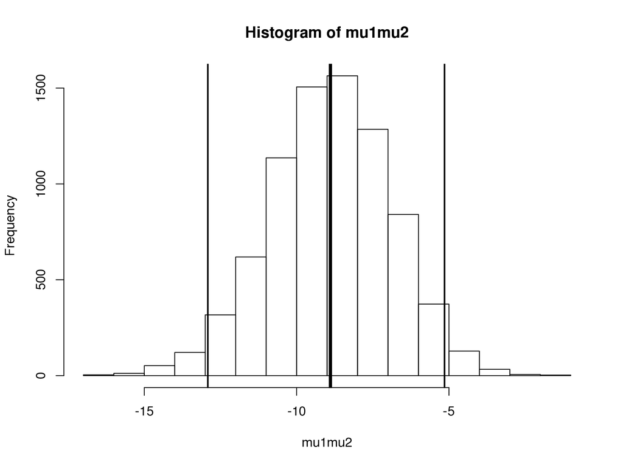